# DV_RProject3

**Authors: Rolando Melendez, Hyunji Seo, Catherine Tu**

## Program file structure

00 Doc - contains .Rmd and .html

01 Data - contains the code to Extract, Transform, and Load our data

02 Data Wrangling - contains our workflows and the code for the visualizations

## Data summary and subset

```r
#Shows the subset and summary of the data frame
source("../01 Data/R_Load_Crime.R", echo = TRUE)
```

```
##
## > require("jsonlite")
```

```
##
## > require("RCurl")
```

```
##
## > dfCr <- data.frame(fromJSON(getURL(URLencode("129.152.144.84:5001/rest/native/?query=\"select * from Chicago_Crimes\""),
## +     httpheader = c(DB =  .... [TRUNCATED]
##
## > head(dfCr)
##   CASE_NUMBER                     BLOCK IUCR    PRIMARY_TYPE
## 1    HY452327        024XX S ARCHER AVE  313         ROBBERY
## 2    HY452338       023XX W CHICAGO AVE 2027       NARCOTICS
## 3    HY452875    085XX S DORCHESTER AVE  810           THEFT
## 4    HY452811       042XX S LANGLEY AVE 1320 CRIMINAL DAMAGE
## 5    HY452336 090XX S SOUTH CHICAGO AVE 4625   OTHER OFFENSE
## 6    HY452337       066XX S LANGLEY AVE  486         BATTERY
##                     DESCRIPTION LOCATION_DESCRIPTION ARREST DOMESTIC
## 1 ARMED; OTHER DANGEROUS WEAPON          GAS STATION  FALSE    FALSE
## 2                   POSS; CRACK                ALLEY   TRUE    FALSE
## 3                     OVER $500            RESIDENCE  FALSE    FALSE
## 4                    TO VEHICLE               STREET  FALSE    FALSE
## 5              PAROLE VIOLATION               STREET   TRUE    FALSE
## 6       DOMESTIC BATTERY SIMPLE               STREET  FALSE     TRUE
##   FBI_CODE                      LOCATION       ID BEAT DISTRICT WARD
## 1        3 (41.847565598, -87.645749253) 10264663  914        9   11
## 2       18 (41.895761856, -87.685705175) 10264570 1212       12   32
## 3        6  (41.73972432, -87.590345854) 10265365  412        4    8
## 4       14 (41.818024121, -87.609218554) 10265263  214        2    4
## 5       26   (41.730387642, -87.5562433) 10264581  423        4    7
## 6      08B (41.774351017, -87.608250919) 10265109  321        3   20
##   COMMUNITY_AREA X_COORDINATE Y_COORDINATE YEAR         LATITUDE
## 1             60      1171590      1887793 2015  41.847599029541
## 2             24      1160571      1905271 2015 41.8958015441895
## 3             45      1187025      1848622 2015 41.7397003173828
## 4             38      1181634      1877110 2015  41.818000793457
## 5             46      1196363      1845302 2015 41.7304000854492
## 6             42      1182032      1861198 2015 41.7743988037109
##           LONGITUDE
## 1 -87.6456985473633
## 2 -87.6856994628906
## 3 -87.5903015136719
## 4 -87.6091995239258
## 5 -87.5561981201172
## 6 -87.6082992553711
```

[output cut: 43 more lines]

```
##  null   :  3944   null   :  3944   Min.   :2015
##  1176352:   384   1900927:   353   1st Qu.:2015
##  1145727:   314   1853720:   318   Median :2015
##  1177338:   241   1906181:   205   Mean   :2015
##  1175078:   184   1849610:   185   3rd Qu.:2015
##  1145011:   150   1910225:   159   Max.   :2015
##  (Other):193224   (Other):193277
##              LATITUDE                  LONGITUDE
##  null            :  3944   null             :  3944
##  41.8834991455078:   457   -87.6278991699219:   721
##  41.8804016113281:   449   -87.6240997314453:   645
##  41.8806991577148:   415   -87.6241989135742:   537
##  41.7546005249023:   396   -87.627799987793 :   460
##  41.8844985961914:   359   -87.7415008544922:   425
##  (Other)         :192421   (Other)          :191709
```

```r
source("../01 Data/R_Load_HealthDemographics.R", echo = TRUE)
```

```
##
## > require("jsonlite")
##
## > require("RCurl")
##
## > dfHlth <- data.frame(fromJSON(getURL(URLencode("129.152.144.84:5001/rest/native/?query=\"select * from Chicago_HealthDemographics\""),
## +     httphe .... [TRUNCATED]
##
## > head(dfHlth)
##   COMMUNITY_AREA_NAME CHILD_BLOOD_LEAD_LV_SCREENING COMMUNITY_AREA
## 1         Rogers Park              364.700012207031              1
## 2          West Ridge              331.399993896484              2
## 3              Uptown              353.700012207031              3
## 4      Lincoln Square              273.299987792969              4
## 5        North Center              178.100006103516              5
## 6           Lake View              179.199996948242              6
##   BIRTH_RATE GENERAL_FERTILITY_RATE LOW_BIRTH_WEIGHT
## 1       16.4                   62.0             11.0
## 2       17.3                   83.3              8.1
## 3       13.1                   50.5              8.3
## 4       17.1                   61.0              8.1
## 5       22.4                   76.2              9.1
## 6       13.5                   38.7              6.3
##   PRENATAL_CARE_FIRST_TRIMESTER PRETERM_BIRTHS TEEN_BIRTH_RATE
## 1                          73.0           11.2            40.8
## 2                          71.1            8.3            29.9
## 3                          77.7           10.3            35.1
## 4                          80.5            9.7            38.4
## 5                          80.4            9.8             8.4
## 6                          79.1            8.1            15.8
##   ASSAULT_HOMICIDE BREAST_CANCER_FEM CANCER_ALL_SITES COLORECTAL_CANCER
## 1              7.7              23.3            176.9              25.3
## 2              5.8              20.2            155.9              17.3
## 3              5.4              21.3            183.3              20.5
## 4              5.0              21.7            153.2               8.6
## 5              1.0              16.6            152.1              26.1
## 6              1.4              20.1            126.9              13.0
##   DIABETES_RELATED FIREARM_RELATED INF_MORT_RATE LUNG_CANCER
## 1             77.1             5.2           6.4        36.7
## 2             60.5             3.7           5.1        36.0
```

[output cut: 91 more lines]

```
##  Min.   : 0.200   Min.   :15.50   Min.   : 2.9   Min.   : 8535
##  1st Qu.: 2.000   1st Qu.:32.30   1st Qu.:13.4   1st Qu.:15467
##  Median : 4.200   Median :38.30   Median :18.5   Median :20489
##  Mean   : 4.913   Mean   :35.83   Mean   :21.6   Mean   :25107
##  3rd Qu.: 6.800   3rd Qu.:40.90   3rd Qu.:29.4   3rd Qu.:29026
##  Max.   :17.600   Max.   :50.20   Max.   :58.7   Max.   :87163
##
##   UNEMPLOYMENT
##  Min.   : 4.2
##  1st Qu.: 7.8
##  Median :11.5
##  Mean   :13.3
##  3rd Qu.:17.4
##  Max.   :40.0
##
```

```r
source("../01 Data/R_Load_PublicSchools.R", echo = TRUE)
```

```
##
## > require("jsonlite")
##
## > require("RCurl")
##
## > dfPS <- data.frame(fromJSON(getURL(URLencode("129.152.144.84:5001/rest/native/?query=\"select * from Chicago_PublicSchools\""),
## +     httpheader =  .... [TRUNCATED]
##
## > head(dfPS)
##   SCHOOL_ID
## 1    610038
## 2    610281
## 3    610185
## 4    609993
## 5    610513
## 6    610212
##                                                       SCHOOL_NAME
## 1                               Abraham Lincoln Elementary School
## 2 Adam Clayton Powell Paideia Community Academy Elementary School
## 3                             Adlai E Stevenson Elementary School
## 4                                 Agustin Lara Elementary Academy
## 5                                   Air Force Academy High School
## 6                               Albany Park Multicultural Academy
##   SCHOOL_TYPE    CITY STATE ZIP_CODE  CPS_PERF_LEVEL      SAFETY
## 1          ES Chicago    IL    60614         Level 1 Very Strong
## 2          ES Chicago    IL    60649         Level 1     Average
## 3          ES Chicago    IL    60652         Level 2      Strong
## 4          ES Chicago    IL    60609         Level 1     Average
## 5          HS Chicago    IL    60609 Not Enough Data     Average
## 6          MS Chicago    IL    60625         Level 1      Strong
##   FAMILY_INVOLVEMENT ENVIRONMENT INSTRUCTION TEACHERS PARENT_ENGAGE
## 1        Very Strong      Strong      Strong   Strong        Strong
## 2             Strong      Strong Very Strong   Strong          Weak
## 3                NDA     Average        Weak      NDA       Average
## 4            Average     Average        Weak  Average       Average
## 5             Strong      Strong     Average  Average       Average
## 6               Weak      Strong      Strong  Average          Weak
##   PARENT_ENV COMMUNITY_AREA COMMUNITY_NAME WARD POLICE_DISTRICT
## 1    Average              7   LINCOLN PARK   43              18
## 2    Average             43    SOUTH SHORE    7               4
```

[output cut: 99 more lines]

```
##  95.5            : 25    Min.   :  0.000   Min.   : 0.00
##  95.0999984741211: 22    1st Qu.:  4.525   1st Qu.:95.10
##  95.5999984741211: 17    Median : 12.250   Median :95.80
##  94.9000015258789: 14    Mean   : 21.086   Mean   :94.38
##  95.9000015258789: 14    3rd Qu.: 26.975   3rd Qu.:96.40
##  96.1999969482422: 14    Max.   :251.600   Max.   :98.50
##  (Other)         :460
##          ISAT_EXCEED_MATH       ISAT_EXCEED_READING COLLEGE_ENROLLMENT
##  null            : 90     null            : 90      Min.   :  21.0
##  22              :  6     5.69999980926514:  9      1st Qu.: 342.2
##  7.90000009536743:  6     11              :  7      Median : 504.0
##  7.59999990463257:  5     5.59999990463257:  7      Mean   : 626.1
##  9.39999961853027:  5     15.6000003814697:  5      3rd Qu.: 790.5
##  9.80000019073486:  5     3.20000004768372:  5      Max.   :4368.0
##  (Other)         :449     (Other)         :443
```

```r
source("../01 Data/R_Load_Socioeconomic.R", echo = TRUE)
```

```
##
## > require("jsonlite")
##
## > require("RCurl")
##
## > dfSocio <- data.frame(fromJSON(getURL(URLencode("129.152.144.84:5001/rest/native/?query=\"select * from Chicago_Socioeconomic\""),
## +     httpheader .... [TRUNCATED]
##
## > head(dfSocio)
##   COMMUNITY_ARE_NAME COMMUNITY_AREA PERCENT_OF_HOUSING_CROWDED
## 1        Rogers Park              1                        7.7
## 2         West Ridge              2                        7.8
## 3             Uptown              3                        3.8
## 4     Lincoln Square              4                        3.4
## 5       North Center              5                        0.3
## 6          Lake View              6                        1.1
##   PERCENT_HH_BELOW_POVERTY PERCENT_AGED_16_UNEMPLOYED
## 1                     23.6                        8.7
## 2                     17.2                        8.8
## 3                     24.0                        8.9
## 4                     10.9                        8.2
## 5                      7.5                        5.2
## 6                     11.4                        4.7
##   PERCENT_AGED_25_WO_HS_DIPLOMA PERCENT_AGED_UNDER_18_OVER_64
## 1                          18.2                          27.5
## 2                          20.8                          38.5
## 3                          11.8                          22.2
## 4                          13.4                          25.5
## 5                           4.5                          26.2
## 6                           2.6                          17.0
##   PER_CAPITA_INCOME HARDSHIP_INDEX
## 1             23939             39
## 2             23040             46
## 3             35787             20
## 4             37524             17
## 5             57123              6
## 6             60058              5
```

#### Explanation of Data:

These data sets were obtained from the City of Chicago Data Portal (https://data.cityofchicago.org/). All three of our visualizations utilized the Chicago_Crimes dataset and implemented an inner join, full join, and right join, each with a different data set.

## Socioeconomic Indicators

```r
#Shows the subset and summary of the data frame
source("../02 Data Wrangling/SocioEconomic_Crimes.R", echo = TRUE)
```

```
##
## > require(tidyr)
```

```
##
## > require(dplyr)
```

```
##
## > require(extrafont)
```

```
## Registering fonts with R
```

```
##
## > require(ggplot2)
```

```
##
## > ndfCr <- dfCr %>% group_by(PRIMARY_TYPE, COMMUNITY_AREA) %>%
## +     summarise(COUNT = n()) %>% arrange(COMMUNITY_AREA)
##
## > pdC <- ndfCr
##
## > pdS <- dfSocio
##
## > ndf <- dplyr::right_join(pdC, pdS, by = "COMMUNITY_AREA")
##
## > SEC <- ndf %>% filter(PRIMARY_TYPE == "BATTERY" |
## +     PRIMARY_TYPE == "BURGLARY" | PRIMARY_TYPE == "CRIMINAL DAMAGE" |
## +     PRIMARY_TYPE == "DE ..." ... [TRUNCATED]
##
## > ggplot() + coord_cartesian() + scale_x_discrete() +
## +     scale_y_continuous() + labs(title = "Chicago Data") + labs(x = paste("Type of Crime"),
## + .... [TRUNCATED]
```

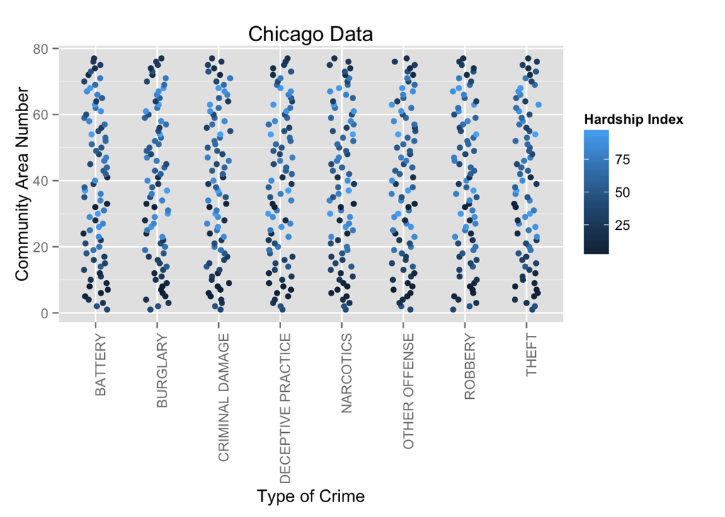

#### Findings:

This visualization aimed to examine the relationship of crime in Chicago in 2015 and Socioeconomic factors. For this visualization, we utilized a right join between the two datasets, with Community Area number as the common measure. Although there are more than 25 different types of crime given through the data set, we limited our analysis to the top eight crime types determined by the highest count of data points.

From this visualization, we can see that the Hardship Index is similar across types of crime for a specific community area. The Hardship Index is indicative of the community environment, just like the other measures like unemployment and income level. Therefore, it seems reasonable to conclude that the crime and hardship levels are consistent within a given community, whether for better or for worse.

## Health Demographic Indicators

```
##
## > require(tidyr)
##
## > require(dplyr)
##
## > require(extrafont)
##
## > require(ggplot2)
##
## > pdH <- dfHlth
##
## > pdC <- dfCr
##
## > summary(pdH)
##      COMMUNITY_AREA_NAME  CHILD_BLOOD_LEAD_LV_SCREENING COMMUNITY_AREA
##  Albany Park   : 1       298.799987792969: 2            Min.   : 1
##  Archer Heights: 1       398.5           : 2            1st Qu.:20
##  Armour Square : 1       133.600006103516: 1            Median :39
##  Ashburn       : 1       134.699996948242: 1            Mean   :39
##  Auburn Gresham: 1       160.800003051758: 1            3rd Qu.:58
##  Austin        : 1       163.100006103516: 1            Max.   :77
##  (Other)       :71       (Other)         :69
##    BIRTH_RATE   GENERAL_FERTILITY_RATE LOW_BIRTH_WEIGHT
##  Min.   : 9.4   Min.   :27.70          Min.   : 3.5
##  1st Qu.:12.9   1st Qu.:60.10          1st Qu.: 7.3
##  Median :15.7   Median :68.30          Median : 8.7
##  Mean   :15.7   Mean   :68.39          Mean   :10.1
##  3rd Qu.:18.5   3rd Qu.:80.70          3rd Qu.:12.7
##  Max.   :22.4   Max.   :94.90          Max.   :19.7
##
##  PRENATAL_CARE_FIRST_TRIMESTER PRETERM_BIRTHS  TEEN_BIRTH_RATE
##  Min.   :63.60                 Min.   : 5.00   Min.   :  1.30
##  1st Qu.:73.30                 1st Qu.: 8.80   1st Qu.: 33.70
##  Median :76.10                 Median :10.80   Median : 49.20
##  Mean   :76.95                 Mean   :11.26   Mean   : 50.06
##  3rd Qu.:80.40                 3rd Qu.:13.70   3rd Qu.: 67.90
##  Max.   :94.50                 Max.   :17.50   Max.   :116.90
##
##  ASSAULT_HOMICIDE BREAST_CANCER_FEM CANCER_ALL_SITES COLORECTAL_CANCER
##  Min.   : 0.00    Min.   : 7.60     Min.   :120.1    Min.   : 8.60
```

[output cut: 96 more lines]

```
##              LATITUDE                  LONGITUDE
##  null            :  3944   null             :  3944
##  41.8834991455078:   457   -87.6278991699219:   721
##  41.8804016113281:   449   -87.6240997314453:   645
##  41.8806991577148:   415   -87.6241989135742:   537
##  41.7546005249023:   396   -87.627799987793 :   460
##  41.8844985961914:   359   -87.7415008544922:   425
##  (Other)         :192421   (Other)          :191709
##
## > pj <- full_join(pdC, pdH, by = "COMMUNITY_AREA") %>%
## +     select(PRIMARY_TYPE, BIRTH_RATE, TEEN_BIRTH_RATE, ASSAULT_HOMICIDE) %>%
## +     arrange(P .... [TRUNCATED]
##
## > ggplot() + coord_cartesian() + scale_x_continuous() +
## +     scale_y_continuous() + facet_wrap(~PRIMARY_TYPE) + labs(title = "City of Chicago Health ..." ... [TRUNCATED]
```

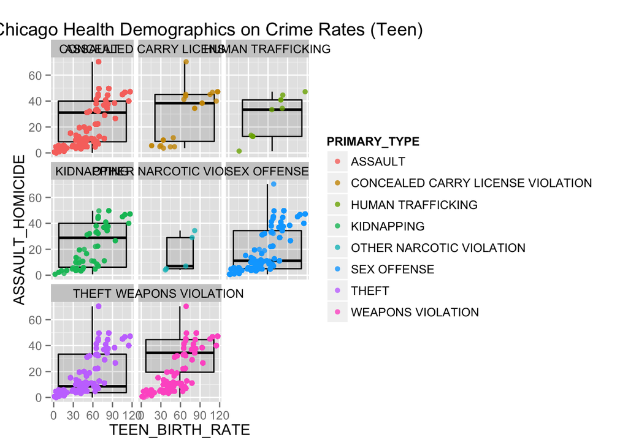

```
##
## > ggplot() + coord_cartesian() + scale_x_continuous() +
## +     scale_y_continuous() + facet_wrap(~PRIMARY_TYPE) + labs(title = "City of Chicago Health ..." ... [TRUNCATED]
```

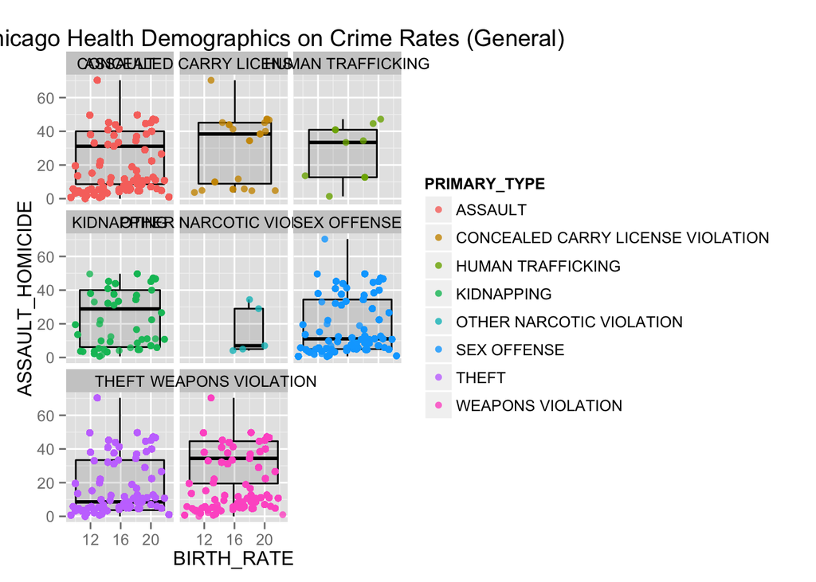

```r
#Shows the subset and summary of the data frame
source("../02 Data Wrangling/HealthDemographics_Crimes.R", echo = TRUE)
```

#### Findings:

This visualization aimed to examine the relationship of crime in Chicago in 2015 and Health Demogrphics. For this visualization, we utilized a full join between the two datasets, with Community Area number as the common measure. This visualization focused on an 8 count spread of 31 total crime types ranging from high to low count of data points. The two visualizations focus on teen birth rate and overall birth rate, respectively. This plots each birthrate on the x-axis and homicide counts on the y-axis.

From the visualizations we can see that in general the distribution as shown in the boxplots for each crime type is very similar between the teen and the overall birth rate data. What can be seen is that for seemingly “less dangerous” crimes (Other Nacotic Violation, Sex Offense, and Theft) the range of the spread of homicide is on the low end. What is clearly apparent is that the birthrate for the overall city seems to have a slightly more steady and stagnant growth in homicide when compared to that of the teen birth rates. In teen birth rates there is a clear correlation between higher birthrate and higher homocide rates. This makes it seem that the more teens get pregnant and give birth the higher their corresponding crime rates are.

## Public School Safety and Student Conduct Indicators

```r
#Shows the subset and summary of the data frame
source("../02 Data Wrangling/PublicSchools_Crimes.R", echo = TRUE)
```

```
##
## > require(tidyr)
##
## > require(dplyr)
##
## > require(extrafont)
##
## > require(ggplot2)
##
## > ndfCr <- dfCr %>% group_by(COMMUNITY_AREA, PRIMARY_TYPE) %>%
## +     summarise(CRIME_COUNT = n())
##
## > dfPS$SAFETY_LEVEL <- factor(dfPS$SAFETY, c("Very Weak",
## +     "Weak", "Average", "Strong", "Very Strong", "NDA"))
##
## > dfCrPS <- inner_join(dfPS, ndfCr, by = c(COMMUNITY_AREA = "COMMUNITY_AREA")) %>%
## +     select(PRIMARY_TYPE, SAFETY_LEVEL, MISCONDUCT_RATE, CRIME_CO .... [TRUNCATED]
##
## > ggplot() + coord_cartesian() + scale_x_discrete() +
## +     scale_y_continuous() + labs(title = "Public School Safety Rating and Misconduct Rate with ..." ... [TRUNCATED]
```

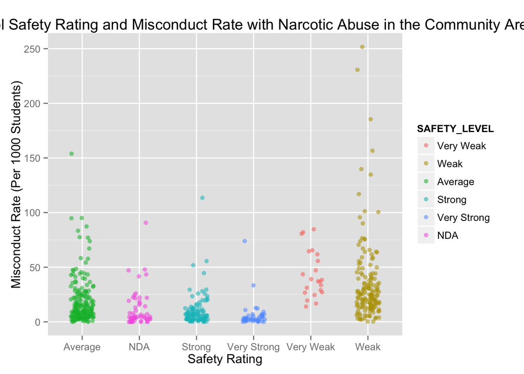

#### Findings:

This visualization examines the correlation of a public school’s Safety Rating and its Rate of Student Misconduct for schools in areas with records of Narcotics crime. We utilized an inner join between the two datasets of Public School Ratings and Crime, with Community Area code as the common measure. We particularly focus on how Narcotics, as one of the more frequently occurring crime types in Chicago, may play a part in the rating and student conduct in public schools located near such crimes.

Unsurprisingly, we find that as Safety Ratings decrease, Misconduct Rates shift upwards. However, there are still high outliers within the schools of “Very Strong” and “Strong” safety ratings, which suggests that there may be other types of crime that may influence the student misconduct at those schools.